[figure not shown]

General Description

INSTRUMENTATION/DRIVER INFO

1. General Description

A: SPECIFICATION

1. COMBINATION METER ASSEMBLY

NOTE:

Specifications of the combination meter vary depending on the market and the grade.

Meter, display

display method

Drive control

indicator needle

operation/needle

reading operation

Speedometer

Stepping motor type Combination meter —

Tachometer

Engine coolant temperature gauge

Fuel gauge

ABS warning light

LED

Combination meter

On/Off

STEERING warning light

AT oil temperature warning light

Driver’s seat belt warning light

Door warning light

Tire pressure warning light

AWD warning light

Hill start assist warning light

VDC warning light / VDC operation indicator light

VDC OFF indicator light

VDC traction mode indicator light

High beam indicator light

Front fog light indicator light

Lighting indicator light

Malfunction indicator light

Airbag warning light

REV indicator light

LED headlight warning light

Meter illumination back light

Light ON

TFT back-up light

Fuel level warning light

On/Off (area near the

E mark is illuminated)

Oil pressure warning light Oil pressure switch

Turns on or off

according to module

control

Charge warning light Generator

Rear differential oil temperature warning light

Rear differential oil

temperature switch

Turn signal indicator light

ard unit

Security/immobilizer indicator light Body integrated unit

Auto leveler warning light

Auto headlight beam

leveler CM

Parking brake/brake fluid level/vacuum pump warning light

Combination meter/

brake fluid level

switch/combination

meter

On/Turns on or off

according to module

control

[figure not shown]

General Description

INSTRUMENTATION/DRIVER INFO

2. MULTI-FUNCTION DISPLAY

NOTE:

Specifications of the multi-function display vary depending on the market and the grade.

B: LOCATION

Refer to “LOCATION” of “INSTRUMENTATION/DRIVER INFO (DIAGNOSTICS)” section. <Ref. to IDI(diag)-

6, LOCATION, Electrical Component Location.>

C: CAUTION

• Before disconnecting connectors of sensors or units, be sure to disconnect the ground cable from battery.

When replacing the audio and MFD parts provided with memory functions, record the memory contents be-

fore disconnecting the battery ground cable.

• Use gloves to avoid damage to and get fingerprints on the glass surface. Wipe off using a soft cloth, if the

part is contaminated.

• When the combination meter assembly has been replaced, be sure to perform the following operations.

– For keyless entry model except for C0, be sure to perform the registration of immobilizer. For the rele-

vant procedures, refer to the “REGISTRATION MANUAL FOR IMMOBILIZER”.

– Be sure to reset the ODO fuel economy value of the multi-function display (MFD). <Ref. to IDI-12, ODO

FUEL ECONOMY VALUE RESET, OPERATION, Multi-function Display (MFD) System.>

• Be careful of the following items. Failing to do so may cause the airbag system malfunction.

– Yellow connectors and harnesses with yellow tapes around them are the connectors and harnesses for

the airbag system. When using a tester on these circuits, follow the cautions of “AIRBAG SYSTEM”. <Ref.

to AB-9, CAUTION, General Description.>

– Be careful not to damage the airbag system wiring harness when servicing the electrical parts around

the steering column.

• When removing, installing or replacing the VDCCM&H/U, VDCCM&H/U bracket, steering wheel or steer-

ing angle sensor (steering roll connector), perform “VDC sensor midpoint setting mode” of the VDC. <Ref. to

VDC-16, VDC SENSOR MIDPOINT SETTING MODE, ADJUSTMENT, VDC Control Module and Hydraulic

Control Unit (VDCCM&H/U).>

ODO indicator

TFT Combination meter —

Trip indicator

ECO gauge

Select lever / shift position indicator

SI-DRIVE mode indicator

Information (intervention) display & indicator

DCCD mode indicator

Cruise control system indicator

• Constant speed cruise

• SET

• Set speed

Display Display method

Self-check screen, triple meter screen, setting screen, boost/accelerator opening angle

screen, preventive safety screen, diagnostic mode screen, fuel economy screen, econ-

omy gauge screen, clock/ambient temperature screen, information screen

TFT

Air conditioner display LCD

Passenger’s airbag ON indicator light

LEDPassenger’s airbag OFF indicator light

Passenger’s seat belt warning light

Meter, display

Operation method,

display method

Drive control

indicator needle

operation/needle

reading operation

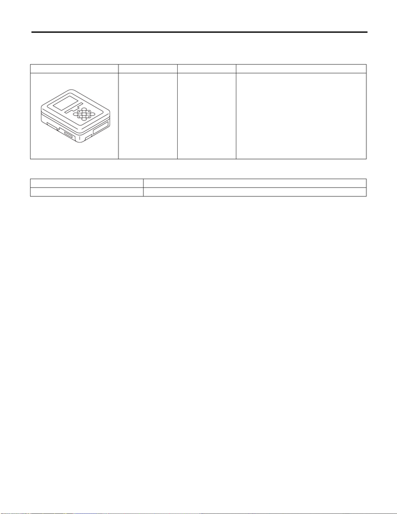

General Description

INSTRUMENTATION/DRIVER INFO

D: PREPARATION TOOL

1. SPECIAL TOOL

2. GENERAL TOOL

ILLUSTRATION TOOL NUMBER DESCRIPTION REMARKS

1B022XU0 SUBARU SELECT

MONITOR III KIT

Used for setting of each function and trouble-

shooting for electrical system.

NOTE:

For detailed operation procedures of SUBARU

SELECT MONITOR III KIT, refer to “PC applica-

tion help for Subaru Select Monitor”.

TOOL NAME REMARKS

Circuit tester Used for measuring resistance and voltage.

ST1B022XU0